# Eksploracyjna analiza danych

Aleksandra Węgrzyn

2023-11-26

### Wprowadzenie

Tematem projektu są zaburzenia snu. Chcę określić, czy istnieją zależności, które decydują o występowaniu chorób związanych ze snem oraz co wpływa na długość snu.

#### Opis zbioru danych

W niniejszym projekcie korzystam ze zbioru danych pochodzącego ze strony [kaggle](https://www.kaggle.com/). Dane dotyczą kwestii zdrowego snu oraz stylu życia. Zbiór danych składa się z 374 wpisów, które zawierają podstawowe charakterystyki poszczególnych osób oraz informacje na temat czasu trwania snu, jakości snu, poziomu stresu, BMI, ciśnienia krwi, tętna, codziennych kroków oraz występowania zaburzeń snu.

Zmienne:

- `Person ID`: identyfikator osoby
- `Gender`: płeć
- `Age`: wiek
- `Occupation`: zawód
- `Sleep Duration`: liczba godzin snu w ciągu dnia
- `Quality of sleep`: jakość snu (subiektywna ocena w skali od 1 do 10)
- `Physical Activity Level`: czas poświęcany na aktywność fizyczną w ciągu dnia (w minutach)
- `Stress level`: doświadczany poziom stresu (subiektywna ocena w skali od 1 do 10)
- `BMI Category`: kategoria wskaźnika masy ciała BMI
- `Blood pressure`: ciśnienie krwi
- `Heart rate`: tętno
- `Daily steps`: dzienna liczba kroków
- `Sleep disorder`: zaburzenia snu, jeśli występują

#### Wczytanie pakietów

Implementuję niezbędne pakiety, które będę wykorzystywać do dalszej analizy.

```r
library(mice)
library(dplyr)
library(ggplot2)
library(corrplot)
library(forcats)
library(psych)
library(corrplot)
library(knitr)
```

### Przygotowanie danych

#### Wczytanie danych

Swoją pracę rozpoczynam od wczytania pliku z danymi.

```r
sleep_data <- read.csv("C:/Users/user/Desktop/projekt EDA/sleep_health_and_lifestyle_dataset.csv", sep = ",")
```

Wykorzystuję funkcje `head()` oraz `tail()`, by sprawdzić kilka początkowych oraz końcowych wartości ze zbioru danych.

```r
head(sleep_data, 4)
```

|  | Person.ID | Gender | Age | Occupation | Sleep.Duration | Quality.of.Sleep | Physical.Activity.Level | Stress.Level | BMI.Category | Blood.Pressure | Heart.Rate | Daily.Steps | Sleep.Disorder |
| --- | --- | --- | --- | --- | --- | --- | --- | --- | --- | --- | --- | --- | --- |
| 1 | 1 | Male | 27 | Software Engineer | 6.1 | 6 | 42 | 6 | Overweight | 126/83 | 77 | 4200 | None |
| 2 | 2 | Male | 28 | Doctor | 6.2 | 6 | 60 | 8 | Normal | 125/80 | 75 | 10000 | None |
| 3 | 3 | Male | 28 | Doctor | 6.2 | 6 | 60 | 8 | Normal | 125/80 | 75 | 10000 | None |
| 4 | 4 | Male | 28 | Sales Representative | 5.9 | 4 | 30 | 8 | Obese | 140/90 | 85 | 3000 | Sleep Apnea |

```r
tail(sleep_data, 3)
```

|  | Person.ID | Gender | Age | Occupation | Sleep.Duration | Quality.of.Sleep | Physical.Activity.Level | Stress.Level | BMI.Category | Blood.Pressure | Heart.Rate | Daily.Steps | Sleep.Disorder |
| --- | --- | --- | --- | --- | --- | --- | --- | --- | --- | --- | --- | --- | --- |
| 372 | 372 | Female | 59 | Nurse | 8.1 | 9 | 75 | 3 | Overweight | 140/95 | 68 | 7000 | Sleep Apnea |
| 373 | 373 | Female | 59 | Nurse | 8.1 | 9 | 75 | 3 | Overweight | 140/95 | 68 | 7000 | Sleep Apnea |
| 374 | 374 | Female | 59 | Nurse | 8.1 | 9 | 75 | 3 | Overweight | 140/95 | 68 | 7000 | Sleep Apnea |

#### Czyszczenie danych

Zaczynam od sprawdzenia struktury posiadanych danych za pomocą funkcji `str()`. W szczególności zależy mi na poznaniu typów poszczególnych zmiennych, by ułatwić sobie proces ich ewentualnej zmiany w przypadku takiej konieczności.

```r
str(sleep_data)
```

```
## 'data.frame':    374 obs. of  13 variables:
##  $ Person.ID              : int  1 2 3 4 5 6 7 8 9 10 ...
##  $ Gender                 : chr  "Male" "Male" "Male" "Male" ...
##  $ Age                    : int  27 28 28 28 28 28 29 29 29 29 ...
##  $ Occupation             : chr  "Software Engineer" "Doctor" "Doctor" "Sales Representative" ...
##  $ Sleep.Duration         : num  6.1 6.2 6.2 5.9 5.9 5.9 6.3 7.8 7.8 7.8 ...
##  $ Quality.of.Sleep       : int  6 6 6 4 4 4 6 7 7 7 ...
##  $ Physical.Activity.Level: int  42 60 60 30 30 30 40 75 75 75 ...
##  $ Stress.Level           : int  6 8 8 8 8 8 7 6 6 6 ...
##  $ BMI.Category           : chr  "Overweight" "Normal" "Normal" "Obese" ...
##  $ Blood.Pressure         : chr  "126/83" "125/80" "125/80" "140/90" ...
##  $ Heart.Rate             : int  77 75 75 85 85 85 82 70 70 70 ...
##  $ Daily.Steps            : int  4200 10000 10000 3000 3000 3000 3500 8000 8000 8000 ...
##  $ Sleep.Disorder         : chr  "None" "None" "None" "Sleep Apnea" ...
```

Zbiór danych składa się z 374 obserwacji i posiada 13 kolumn.

Z zestawu danych usuwam kolumny `Person ID` oraz `Blood Pressure`, ponieważ nie będą mi one potrzebne w dalszej części analizy.

```r
sleep_data <- sleep_data %>%
  select(-c(Person.ID, Blood.Pressure))
```

Sprawdzam czy w zestawie danych znajduja się braki. Dokonuję tego za pomocą funkcji `md.pattern` pochodzącej z pakietu `mice`.

```
##  /\     /\
## {  `---'  }
## {  O   O  }
## ==>  V <==  No need for mice. This data set is completely observed.
##  \  \|/  /
##   `-----'
```

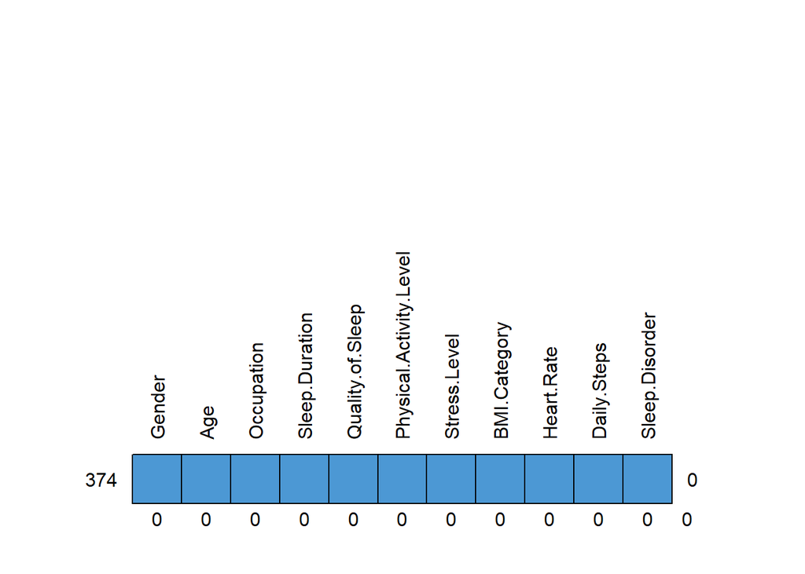

```
##     Gender Age Occupation Sleep.Duration Quality.of.Sleep
## 374      1   1          1              1                1
##          0   0          0              0                0
##     Physical.Activity.Level Stress.Level BMI.Category Heart.Rate Daily.Steps
## 374                       1            1            1          1           1
##                           0            0            0          0           0
##     Sleep.Disorder
## 374              1 0
##                  0 0
```

```r
md.pattern(sleep_data, rotate.names = TRUE)
```

Jak można zauważyć, zbiór danych nie posiada wartości brakujących.

#### Działania usprawniające strukturę

W zestawie danych występują następujące zmienne tekstowe: `Gender`, `Occupation`, `BMI Category` oraz `Sleep Disorder`. Przyjrzę się kolejno każdej z nich, by sprawdzić je pod kątem tego, czy posiadają odpowiedni typ.

Zmienne `Gender` oraz `Occupation`

Dokonuję zmiany zmiennych `Gender` oraz `Occupation` określających kolejno płeć oraz wykonywany zawód na typ czynnikowy `factor`. Pozwoli to na ułatwienie dalszej analizy oraz wizualizacji danych.

```r
sleep_data$Gender <- as.factor(sleep_data$Gender)
sleep_data$Occupation <- as.factor(sleep_data$Occupation)
```

```r
table(sleep_data$Gender)
```

```
##
## Female   Male
##    185    189
```

Podział pod względem płci w badanej grupie jest dość wyrównany tj. 185 kobiet oraz 189 mężczyzn.

Przyjrzę się dokładniej zmiennej dotyczącej wykonywanego zawodu.

```r
table(sleep_data$Occupation)
```

```
##
##           Accountant               Doctor             Engineer
##                   37                   71                   63
##               Lawyer              Manager                Nurse
##                   47                    1                   73
## Sales Representative          Salesperson            Scientist
##                    2                   32                    4
##    Software Engineer              Teacher
##                    4                   40
```

```r
sleep_data <- sleep_data %>%
  mutate(Occupation = fct_lump_n(sleep_data$Occupation,
                                 n = 6,
                                 other_level = "Other"),
         Occupation = fct_infreq(Occupation),
         Occupation = fct_rev(Occupation))
```

Do zaprezentowania sformatowanych danych wykorzystam wykres słupkowy.

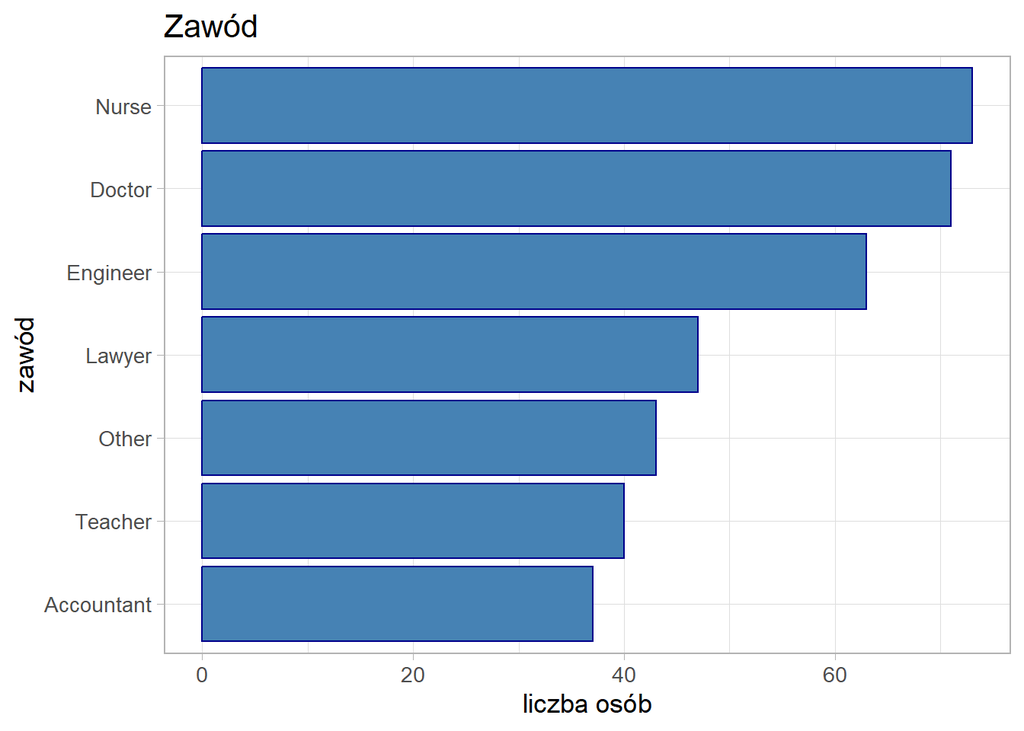

```r
sleep_data %>%
  ggplot() +
  geom_bar(aes(y = Occupation),
           color = "darkblue",
           fill = "steelblue") +
  theme_light(base_size = 13) +
  labs(title = "Zawód",
       x = "liczba osób",
       y = "zawód")
```

Z powyższej wizualizacji można zauważyć, że w grupie badanych osób dominują te, które wykonują zawody medyczne: lekarze i pielęgniarki. Najmniej liczną grupę stanowią osoby obejmujące stanowisko w księgowości.

Zmienna `BMI Category`

```r
table(sleep_data$BMI.Category)
```

```
##
##        Normal Normal Weight         Obese    Overweight
##           154            17            55           148
```

```r
sleep_data$BMI.Category <- as.factor(sleep_data$BMI.Category)
levels(sleep_data$BMI.Category) <- c("Normal", "Normal Weight", "Overweight","Obese")
```

Dla powyższej zmiennej można zobaczyć wśród kategorii podział na `Normal` oraz `Normal Weight`. Są one zbliżone pod względem znaczenia, a ponadto klasa `Normal Weight` jest mało liczna. W związku z powyższym, dokonuję połączenia tych klas w jedną klasę o nazwie `Normal weight`. Wykorzystuję do tego funkcję `fct_collapse()` pochodzącą z pakietu `forcats`.

```r
sleep_data <- sleep_data %>%
  mutate(BMI.Category = fct_collapse(BMI.Category,
                                     Obese = "Obese",
                                     Overweight = "Overweight",
                                     "Normal weight" = c("Normal", "Normal Weight")))
```

Wprowadzone zmiany ponownie wyświetlam za pomocą tabeli.

```r
table(sleep_data$BMI.Category)
```

```
##
## Normal weight    Overweight         Obese
##           171            55           148
```

Widać wyraźnie, iż główną grupę badanych stanowią osoby, dla których wskaźnik BMI mieści się w normie. Chcę się dowiedzieć, jak wygląda powyższa kwestia uwzględniając podział na płeć. Przedstawiam wyniki przy użyciu wykresu kolumnowego.

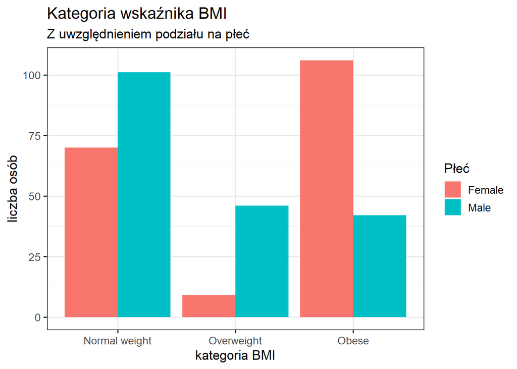

```r
sleep_data %>%
  ggplot() +
  geom_bar(aes(x = BMI.Category, fill = Gender),
           position = "dodge") +
  theme_bw(base_size = 13) +
  labs(title = "Kategoria wskaźnika BMI",
       subtitle = "Z uwzględnieniem podziału na płeć",
       x = "kategoria BMI",
       y = "liczba osób",
       fill = "Płeć")
```

Zmienna `Sleep Disorder`

```r
table(sleep_data$Sleep.Disorder)
```

```
##
##    Insomnia        None Sleep Apnea
##          77         219          78
```

Zmienna `Sleep Disorder` przyjmuje ograniczoną liczbę kategorii występowania danego zaburzenia snu. Powinna zatem zostać potraktowana jako zmienna kategoryczna. Dokonuję odpowiednich przekształceń i zamieniam ją na typ `factor`.

```r
sleep_data$Sleep.Disorder <- factor(sleep_data$Sleep.Disorder)
```

Zmienna `Stress Level`

```r
table(sleep_data$Stress.Level)
```

```
##
##  3  4  5  6  7  8
## 71 70 67 46 50 70
```

Zmienna `Stress Level` określa subiektywną ocenę poziomu odczuwanego stresu przyjmując skalę od 1 do 10. Powinna być ona traktowana jako zmienna typu wyliczeniowego `factor`. Dokonuję zatem zmiany typu zmiennej oraz ustalam przedziały dla kolejnych poziomów odczuwanego stresu. Decyduję się na trzy poziomy kolejno: `Low` (1-3), `Medium` (4-7) oraz `High` (8-10).

```r
przedzialy <- c(0, 3, 7, 10)

sleep_data$Stress.Level <- cut(sleep_data$Stress.Level,
                               breaks = przedzialy,
                               labels = c("Low", "Medium", "High"))
```

Przedstawiam wyniki za pomocą wykresu kolumnowego.

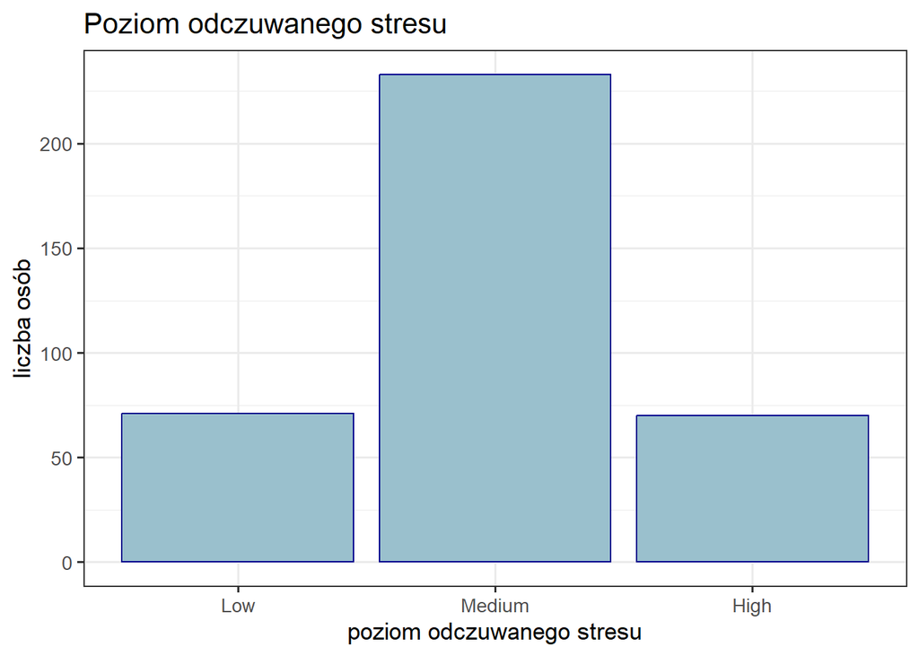

```r
sleep_data %>%
  ggplot() +
  geom_bar(aes(x = Stress.Level),
           color = "darkblue", fill = "lightblue3") +
  theme_bw(base_size = 13) +
  labs(title = "Poziom odczuwanego stresu",
       x = "poziom odczuwanego stresu",
       y = "liczba osób")
```

Zdecydowana większość badanej grupy deklaruje odczuwanie stresu na umiarkowanym poziomie.

Zmienna `Quality of Sleep`

```r
table(sleep_data$Quality.of.Sleep)
```

```
##
##   4   5   6   7   8   9
##   5   7 105  77 109  71
```

Zmienna `Quality of Sleep` określa subiektywną ocenę jakości snu przyjmując skalę od 1 do 10. Postępuję z nią analogicznie jak w przypadku zmiennej `Stress Level`. Zmieniam jedynie nazwy poszczególnych kategorii, by lepiej określały daną zmienną.

```r
przedzialy <- c(0, 3, 7, 10)

sleep_data$Quality.of.Sleep <- cut(sleep_data$Quality.of.Sleep,
                                   breaks = przedzialy,
                                   labels = c("Poor", "Good", "Very good"))
```

```r
table(sleep_data$Quality.of.Sleep)
```

```
##
##      Poor      Good Very good
##         0       194       180
```

Osoby badane oceniają jakość swojego snu jako dobrą lub bardzo dobrą. Co ciekawe, żadna z osób nie deklaruje słabej jakości snu mimo, że u części z nich występują zaburzenia z nim związane.

Pozostałe zmienne są typowo ilościowe, dlatego na tym etapie nie ma konieczności wprowadzania w nich jakichkolwiek zmian.

### Poznanie poszczególnych zmiennych ilościowych

Zmienna `Age`

```r
summary(sleep_data$Age)
```

```
##    Min. 1st Qu.  Median    Mean 3rd Qu.    Max.
##   27.00   35.25   43.00   42.18   50.00   59.00
```

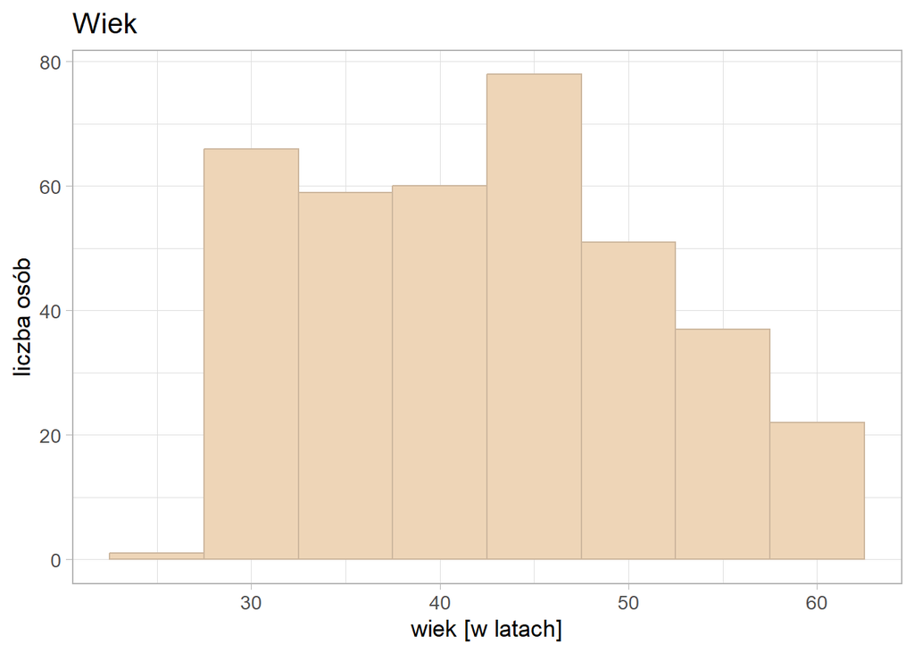

```r
sleep_data %>%
  ggplot() +
  geom_histogram(mapping = aes(x = Age),
                 binwidth = 5,
                 color = "bisque3", fill = "bisque2") +
  theme_light(base_size = 13) +
  labs(title = "Wiek",
       x = "wiek [w latach]",
       y = "liczba osób")
```

Można stwierdzić, że średni wiek osób to 42.18 lat. Najstarsza osoba ma 59 lat, a najmłodsza 27. Połowa osób objętych badaniem mieści się w przedziale wiekowym 35-50 lat. Jednakże należy pamiętać o tym, iż powyższe statystyki dotyczą osób, u których występują zaburzenia snu jak i tych, które ich nie mają. Uwzględnię tę kwestię w późniejszym etapie analizy.

Zmienna `Sleep duration`

```r
summary(sleep_data$Sleep.Duration)
```

```
##    Min. 1st Qu.  Median    Mean 3rd Qu.    Max.
##   5.800   6.400   7.200   7.132   7.800   8.500
```

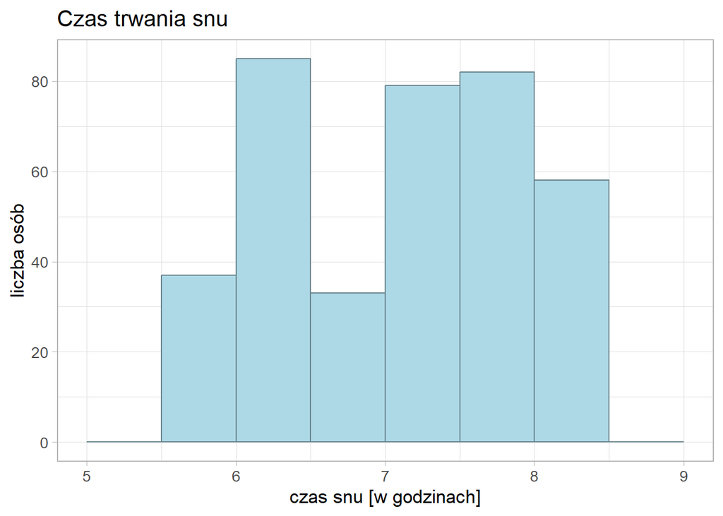

```r
sleep_data %>%
  ggplot() +
  geom_histogram(mapping = aes(x = Sleep.Duration),
                 breaks = seq(5, 9, 0.5),
                 color = "lightblue4", fill = "lightblue") +
  theme_light(base_size = 13) +
  labs(title = "Czas trwania snu",
       x = "czas snu [w godzinach]",
       y = "liczba osób")
```

Zmienna `Physical activity level`

```r
summary(sleep_data$Physical.Activity.Level)
```

```
##    Min. 1st Qu.  Median    Mean 3rd Qu.    Max.
##   30.00   45.00   60.00   59.17   75.00   90.00
```

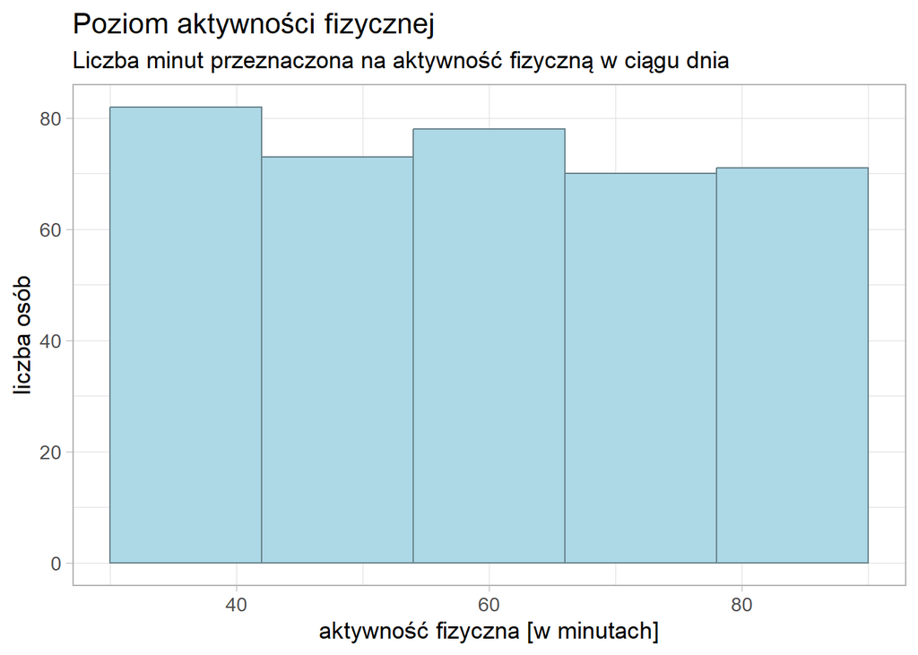

```r
sleep_data %>%
  ggplot() +
  geom_histogram(mapping = aes(x = Physical.Activity.Level),
                 bins = 6,
                 color = "lightblue4", fill = "lightblue") +
  theme_light(base_size = 13) +
  labs(title = "Poziom aktywności fizycznej",
       subtitle = "Liczba minut przeznaczona na aktywność fizyczną w ciągu dnia",
       x = "aktywność fizyczna [w minutach]",
       y = "liczba osób")
```

Rozkład dotyczący czasu przeznaczonego na aktywność fizyczną jest jednostajny. Nie widać znaczących różnic wśród osób poddanych badaniu. Każda z osób podejmuje się aktywności fizycznej w ciągu dnia przez co najmniej 30 minut.

Zmienna `Daily Steps`

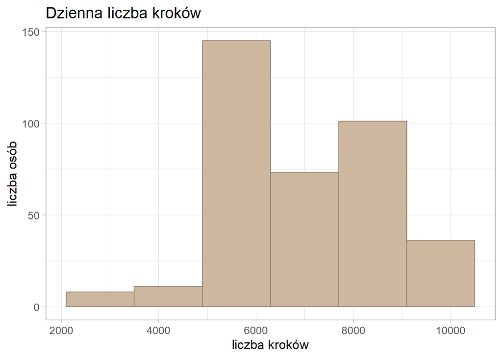

```r
sleep_data %>%
  ggplot() +
  geom_histogram(mapping = aes(x = Daily.Steps),
                 bins = 6,
                 color = "bisque4", fill = "bisque3") +
  theme_light(base_size = 13) +
  labs(title = "Dzienna liczba kroków",
       x = "liczba kroków",
       y = "liczba osób")
```

W przypadku rozkładu zmiennej `Daily Steps` można zaobserwować asymetrię lewostronną. Zatem większa część badanych wykonuje w ciągu dnia liczbę kroków mieszczacą się powyżej średniej wartości.

Zmienna `Heart rate`

```r
summary(sleep_data$Heart.Rate)
```

```
##    Min. 1st Qu.  Median    Mean 3rd Qu.    Max.
##   65.00   68.00   70.00   70.17   72.00   86.00
```

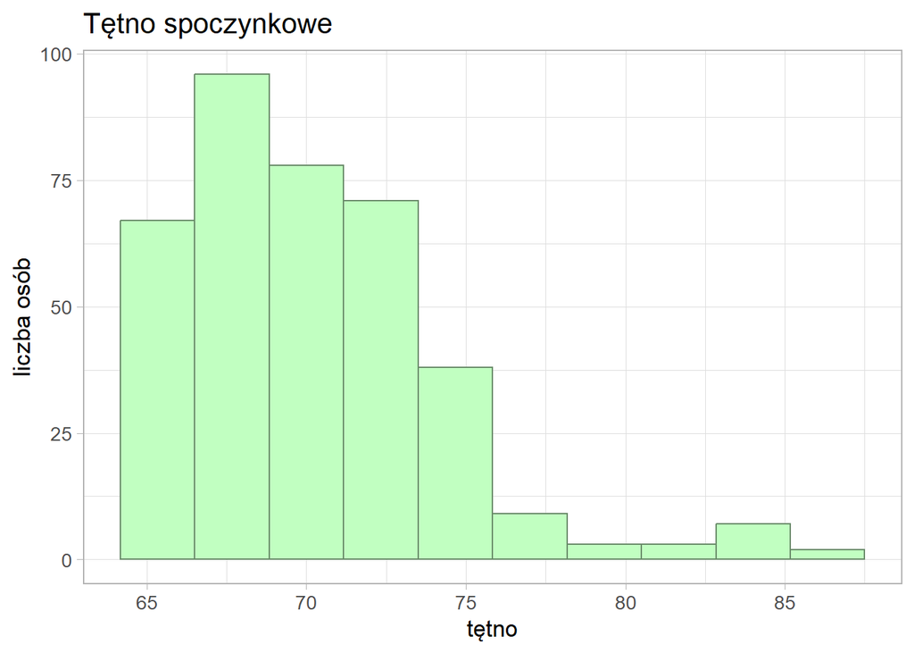

```r
sleep_data %>%
  ggplot() +
  geom_histogram(mapping = aes(x = Heart.Rate),
                 bins = 10,
                 color = "darkseagreen4", fill = "darkseagreen1") +
  theme_light(base_size = 13) +
  labs(title = "Tętno spoczynkowe",
       x = "tętno",
       y = "liczba osób")
```

#### Zależności między zmiennymi

W celu zbadania ewentualnych współzależności między zmiennymi ilościowymi, zastosowałam współczynnik korelacji rangowej Spearmana. Następnie utworzyłam wizualizację macierzy korelacji, aby ułatwić interpretację zależności między zmiennymi.

```r
cor = cor(sleep_data[,c("Physical.Activity.Level", "Age", "Heart.Rate", "Daily.Steps", "Sleep.Duration")],
          method = "spearman")
round(cor, 2)
```

```
##                         Physical.Activity.Level   Age Heart.Rate Daily.Steps
## Physical.Activity.Level                    1.00  0.14       0.16        0.79
## Age                                        0.14  1.00      -0.25       -0.04
## Heart.Rate                                 0.16 -0.25       1.00        0.09
## Daily.Steps                                0.79 -0.04       0.09        1.00
## Sleep.Duration                             0.21  0.31      -0.61        0.01
##                         Sleep.Duration
## Physical.Activity.Level           0.21
## Age                               0.31
## Heart.Rate                       -0.61
## Daily.Steps                       0.01
## Sleep.Duration                    1.00
```

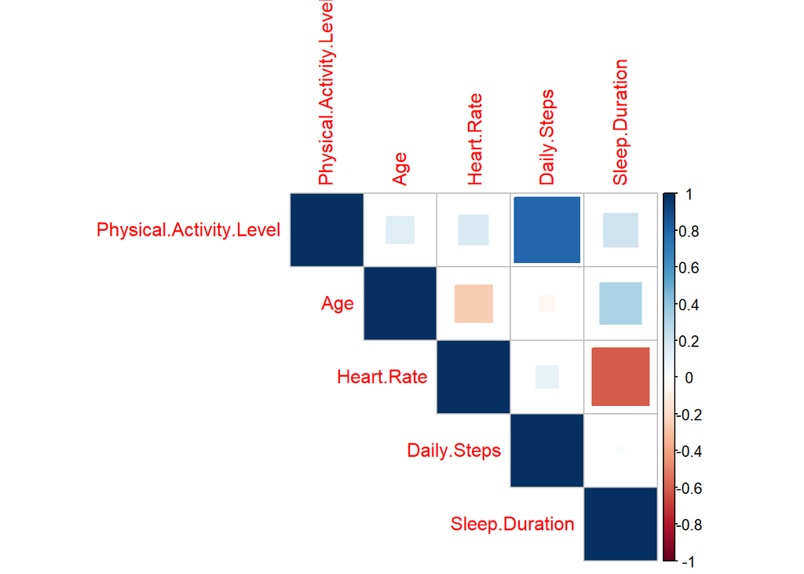

```r
corrplot(cor, method = "square", type = "upper")
```

Powyższy wykres pozwala mi ustalić wstępne spostrzeżenia:

- Między długością snu a poziomem aktywności fizycznej występuje dodatnia zależność korelacyjna
- Między długością snu a wiekiem występuje dodatnia zależność korelacyjna
- Dzienna liczba wykonywanych kroków nie wpływa na długość snu.

### Analiza danych

Za pomocą odpowiednich wizualizacji danych skupię się na identyfikacji kluczowych cech oraz czynników, które w wyraźny sposób wpływają na występowanie zaburzeń snu u poszczególnych osób. W niektórych wizualizacjach uwzględnię podział ze względu na płeć oraz zawód.

Pytania badawcze:

1. Czy występuje zależność między zaburzeniami snu a wiekiem?
2. Czy widoczne są różnice w występowaniu zaburzeń snu w zależności od płci?
3. Czy wykonywany zawód ma wpływ na występowanie zaburzeń snu?
4. Czy istnieje zależność między wiekiem a długością snu, uwzględniając różnice w kategoriach wskaźnika BMI?
5. Czy występuje zależność między odczuwanym poziomem stresu a długością snu?
6. Czy kobiety, które odczuwają wysoki poziom stresu śpią krócej od mężczyzn?
7. Czy istnieje zależność między obejmowanym zawodem a poziomem stresu?
8. Czy istnieje zależność między poziomem tętna a jakością snu?

#### 1. Czy występuje zależność między zaburzeniami snu a wiekiem?

Podczas badania rozkładu rozkład zmiennej opisującej wiek zauważyłam, iż zaburzenia snu występują głównie wśród osób należących do przedziału wiekowego 35 - 50 lat. Jednakże odnosiło się to zarówno do osób, u których występują zaburzenia snu, jak i do tych, którzy ich nie mają. Uwzględnię zatem tę kwestię i wyznaczę statystyki opisowe ograniczając się do osób, które doświadczają problemów ze snem.

```r
sd_data <- sleep_data %>%
  filter(Sleep.Disorder != "None")

summary(sd_data$Age)
```

```
##    Min. 1st Qu.  Median    Mean 3rd Qu.    Max.
##   28.00   43.00   45.00   46.63   51.00   59.00
```

#### 2. Czy widoczne są różnice w występowaniu zaburzeń snu w zależności od płci?

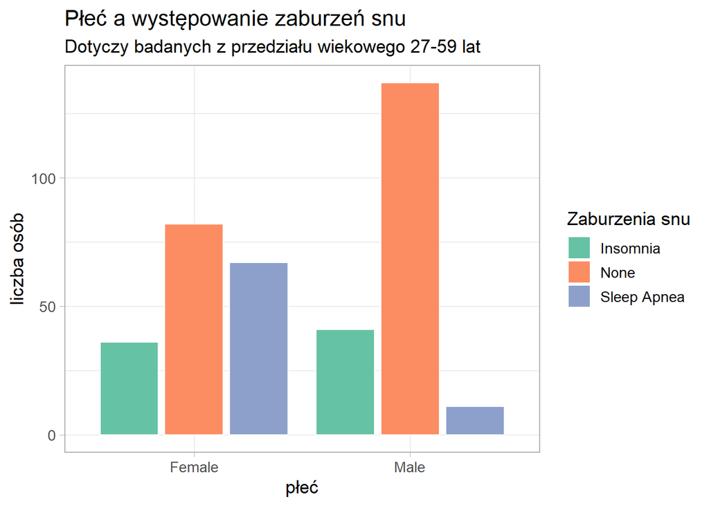

W przypadku mężczyzn zaburzenia snu występują zdecydowanie rzadziej niż ma to miejsce w przypadku kobiet. W populacji kobiet można zauważyć wyraźnie większą różnice w obecności zaburzenia jakim jest bezdech senny (`Sleep Apnea`). Jeśli chodzi o kwestie bezsenności, dotyka ona obu płci w podobnym stopniu.

#### 3. Czy wykonywany zawód ma wpływ na występowanie zaburzeń snu?

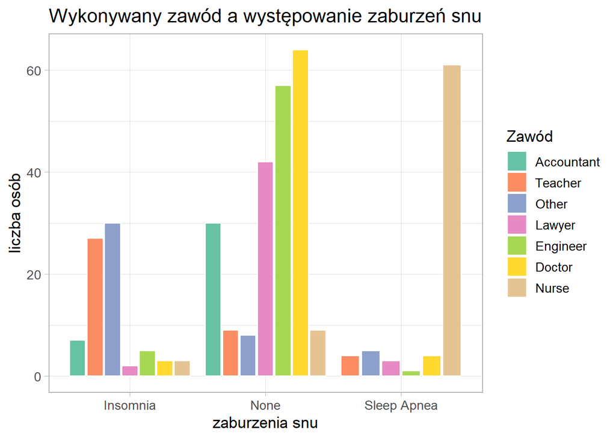

Można zauważyć, iż brak problemów ze snem dotyczy głównie osób, które obejmują stanowiska postrzegane jako prestiżowe tj. lekarz, prawnik, inżynier, księgowy.

#### 4. Czy istnieje zależność między wiekiem a długością snu, uwzględniając różnice w kategoriach wskaźnika BMI?

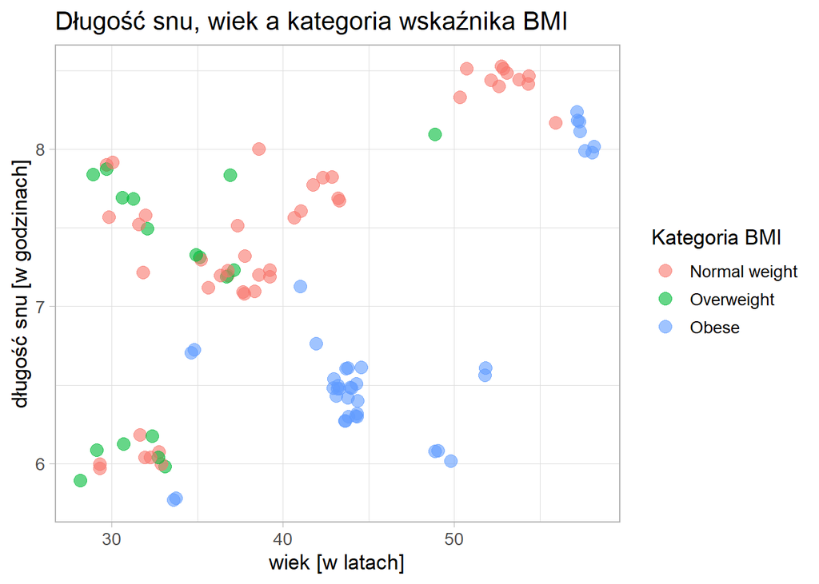

Na podstawie powyższej wizualizacji można stwierdzić, iż wystepuje pewna zależność między wiekiem a długością snu. Oznacza to, iż im starszym się jest, tym śpi się dłużej. Co ciekawe, wspomnianą współzależność można dostrzec we wszystkich kategoriach wskaźnika BMI - zatem niezależnie od tego, czy wskaźnik BMI danej osoby wskazuje na otyłość bądź wagę w normie.

#### 5. Czy występuje zależność między odczuwanym poziomem stresu a długością snu?

```r
sleep_data %>%
  group_by(Stress.Level)%>%
  summarise(średnia = mean(Sleep.Duration),
            mediana = median(Sleep.Duration),
            odch.st = sd(Sleep.Duration))
```

| Stress.Level | średnia | mediana | odch.st |
| --- | --- | --- | --- |
| Low | 8.226761 | 8.2 | 0.21906147 |
| Medium | 7.123605 | 7.2 | 0.52988357 |
| High | 6.050000 | 6.0 | 0.09128709 |

Na podstawie wyznaczonych statystyk można zauważyć, że najdłuższy sen dotyczy osób, które oceniają odczuwany przez siebie poziom stresu jako niski. Osoby, które odczuwają umiarkowany poziom stresu charakteryzuje najwyższe odchylenie standardowe względem pozostałych. Oznacza to, że najbardziej zróżnicowany czas snu występuje u osób, które doświadczają stresu na umiarkowanym poziomie.

Jak można się było spodziewać istnieje zależność między poziomem odczuwanego stresu, a długością snu. Im jest się bardziej zestresowanym, tym czas snu jest krótszy.

#### 6. Czy kobiety, które odczuwają wysoki poziom stresu śpią krócej od mężczyzn?

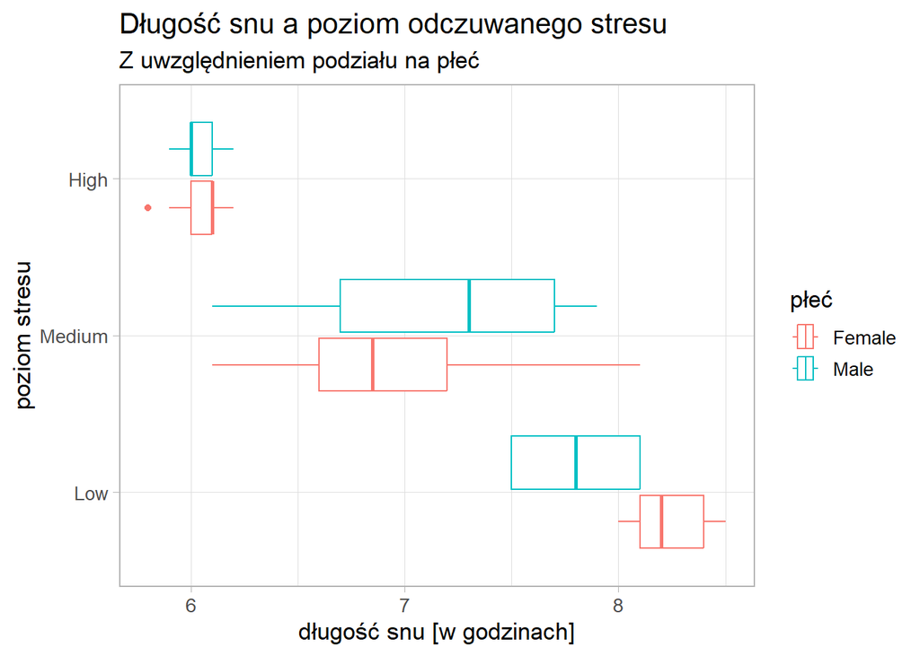

Dla pewności policzę jeszcze statystyki opisowe, które pozwolą mi mieć lepszy ogląd na sytuację.

| Gender | Stress.Level | średnia | mediana | odch.st | min | max | Q1 | Q3 |
| --- | --- | --- | --- | --- | --- | --- | --- | --- |
| Female | Low | 8.252239 | 8.20 | 0.18369788 | 8.0 | 8.5 | 8.1 | 8.4 |
| Female | Medium | 6.891667 | 6.85 | 0.39276847 | 6.1 | 8.1 | 6.6 | 7.2 |
| Female | High | 6.050000 | 6.10 | 0.09613753 | 5.8 | 6.2 | 6.0 | 6.1 |
| Male | Low | 7.800000 | 7.80 | 0.34641016 | 7.5 | 8.1 | 7.5 | 8.1 |
| Male | Medium | 7.254362 | 7.30 | 0.55306068 | 6.1 | 7.9 | 6.7 | 7.7 |
| Male | High | 6.050000 | 6.00 | 0.08783101 | 5.9 | 6.2 | 6.0 | 6.1 |

#### 7. Czy istnieje zależność między obejmowanym zawodem a poziomem stresu?

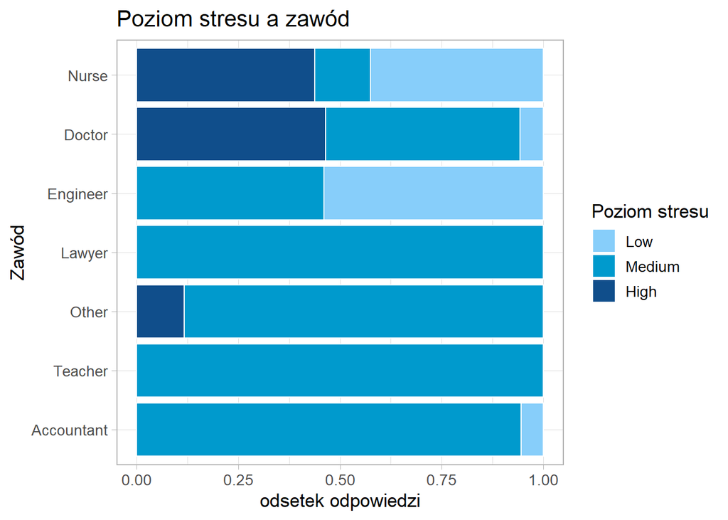

Można zauwazyć, że pracownicy związani z opieką zdrowotną tj. pielęgniarki oraz lekarze często doświadczają wysokiego poziomu stresu. Inżynierowie wydają się odczuwać najniższy poziom stresu w porównaniu do innych zawodów. W pozostałych przypadkach poziom stresu jest zazwyczaj umiarkowany.

#### 8. Czy istnieje zależność między poziomem tętna a jakością snu?

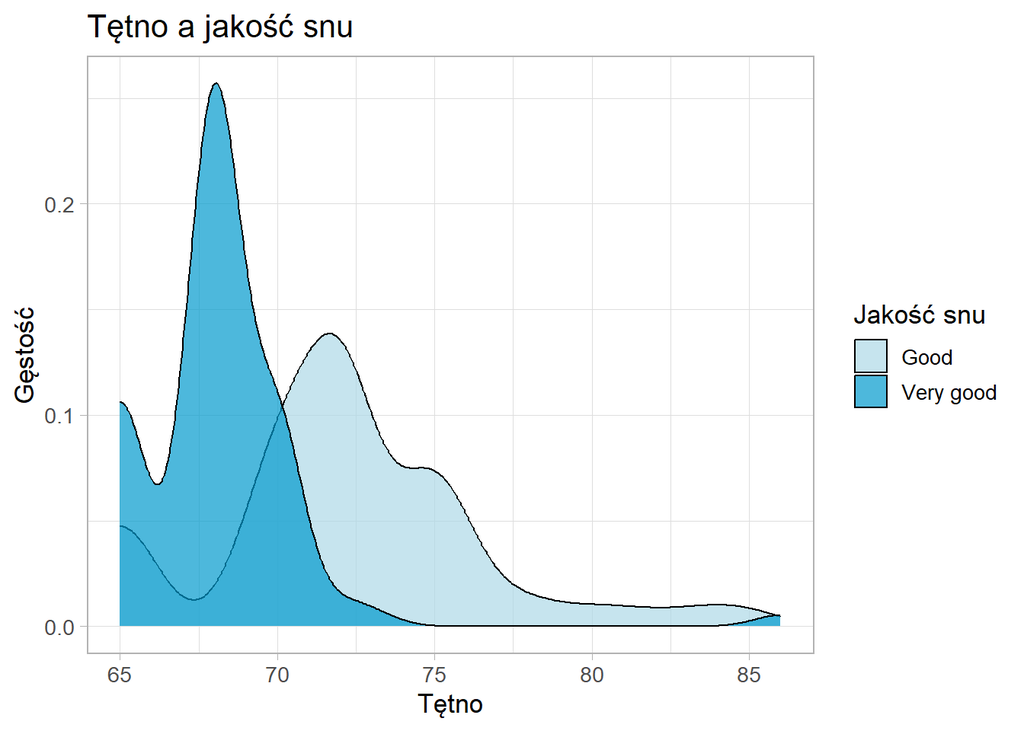

Na podstawie powyższej wizualizacji wyraźnie widać, że osoby których tętno mieści się w granicach 65 - 70 uderzeń serca na minutę wykazują najlepszą jakość snu.

Można zatem stwierdzić istnienie zależności między poziomem tętna a jakością snu.